# Fundamentals of ggplot2

### Exercise:

1. Take your boxplot from the previous exercise and add a layer that displays the values of the individual points on each box-and-whisker plot.

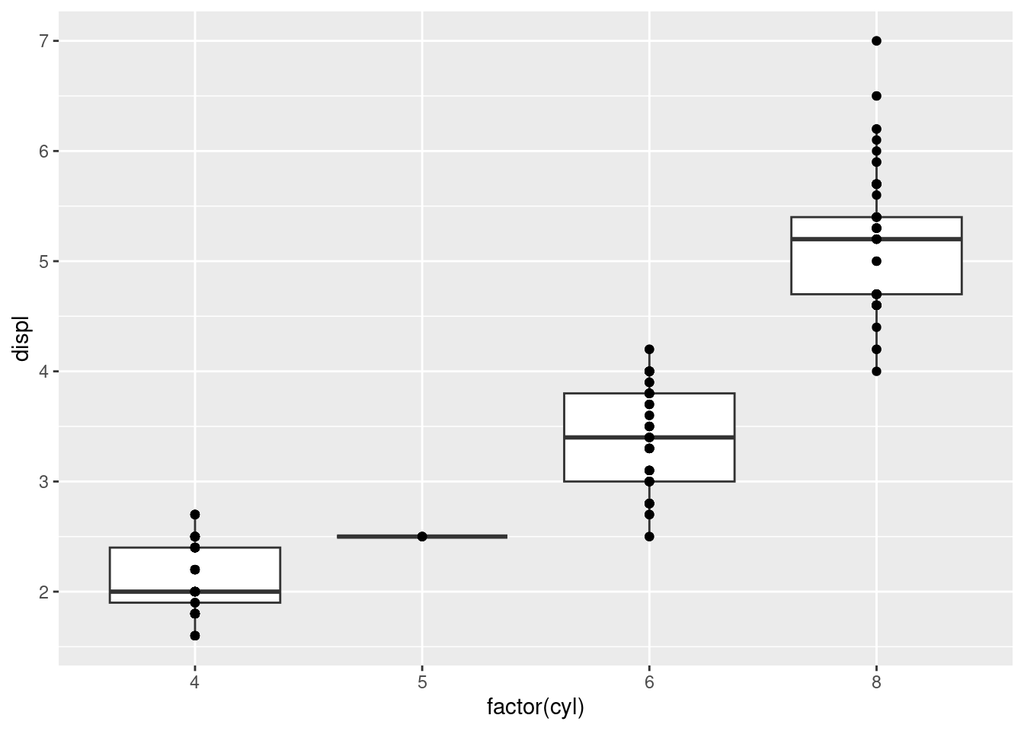

```r
#YOUR CODE HERE
ggplot(mpg, aes(x = factor(cyl), y = displ)) +
  geom_boxplot() +
  geom_point()
```

## Position adjustments

In addition to a default statistical transformation, each geom also has a default position adjustment which specifies how different components should be positioned relative to each other. This position is noticeable in a geom_bar if you map a different variable to the colour visual characteristic:

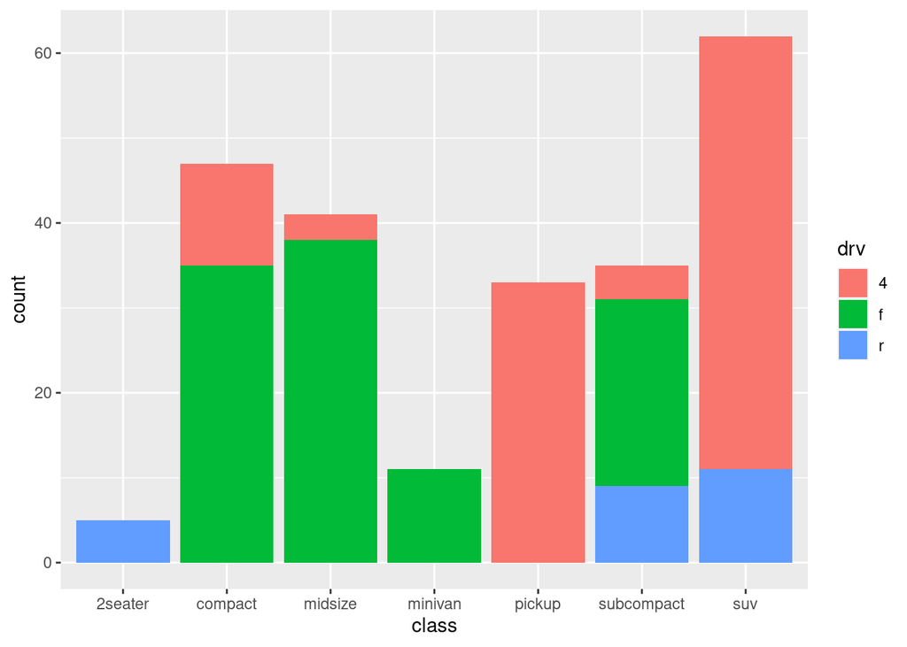

```r
# bar chart of class, coloured by drive (front, rear, 4-wheel)
ggplot(mpg, aes(x = class, fill = drv)) +
  geom_bar()
```

The geom_bar by default uses a position adjustment of ‘stack’, which makes each rectangle’s height proportional to its value and stacks them on top of each other. We can use the position argument to specify what position adjustment rules to follow:

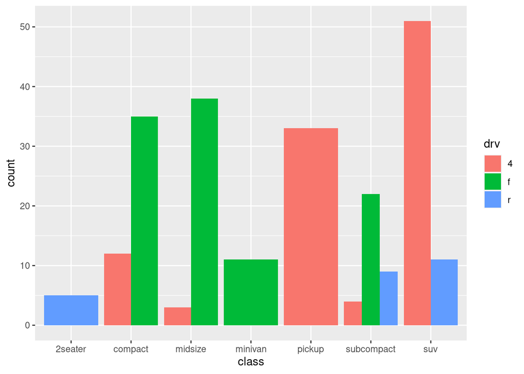

```r
# position = "dodge": values next to each other
ggplot(mpg, aes(x = class, fill = drv)) +
  geom_bar(position = "dodge")
```

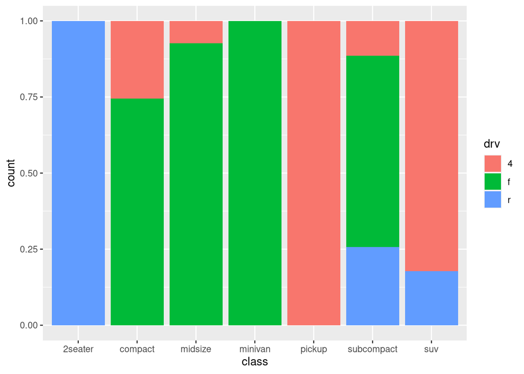

```r
# position = "fill": percentage chart
ggplot(mpg, aes(x = class, fill = drv)) +
  geom_bar(position = "fill")
```

Check the documentation for each particular geom to learn more about its positioning adjustments.

### Exercise:

1. Take your box-and-whisker plot from the previous exercise and use `position = "jitter"` in the point geometry layer. What happens?

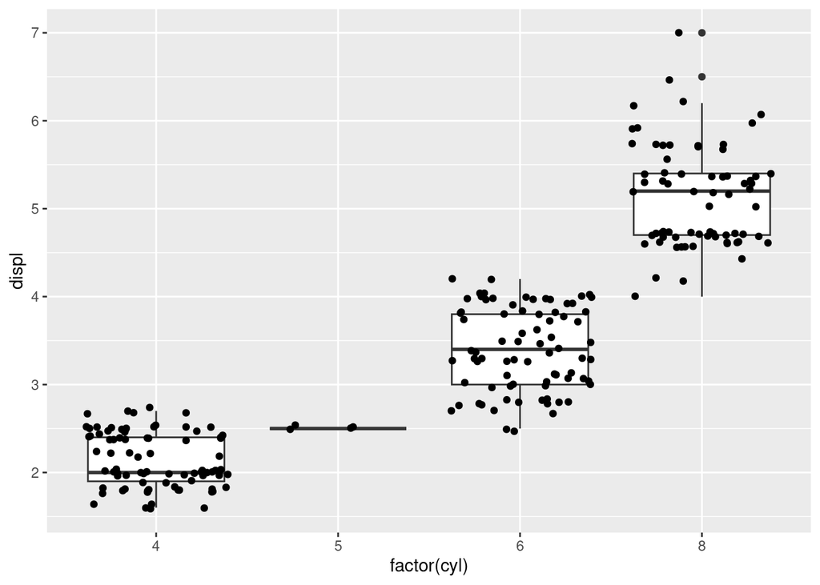

```r
# YOUR CODE HERE
ggplot(mpg, aes(x = factor(cyl), y = displ)) +
  geom_boxplot() +
  geom_point(position = "jitter")
```

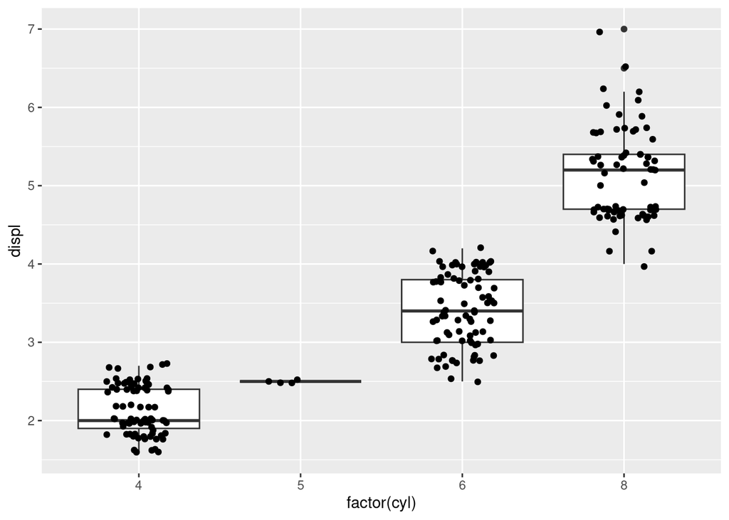

```r
ggplot(mpg, aes(x = factor(cyl), y = displ)) +
  geom_boxplot() +
  geom_jitter(width = 0.2)
```

2. Create a histogram of the distribution of highway mileage values in mpg. Colour the bars by the drive type. Experiment with the position argument in the histogram geometry. What happens?

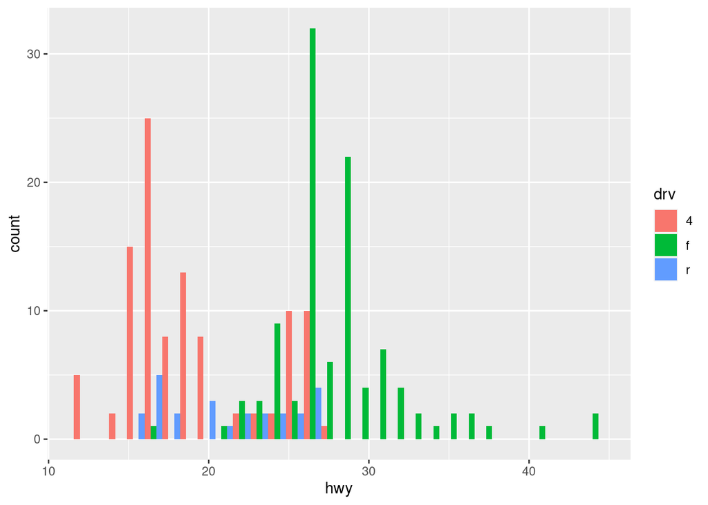

```r
# YOUR CODE HERE
ggplot(mpg, aes(x = hwy, fill = drv)) +
  geom_histogram(position = "dodge")
```

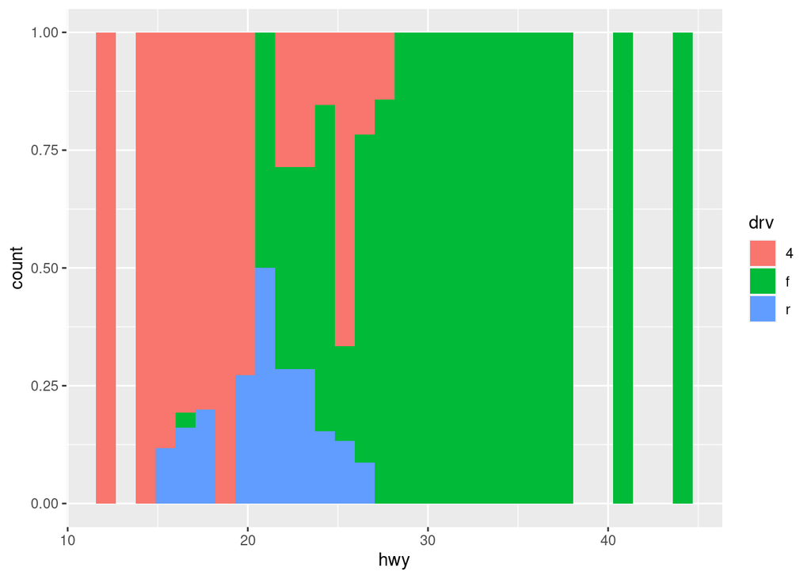

```r
ggplot(mpg, aes(x = hwy, fill = drv)) +
  geom_histogram(position = "fill")
```

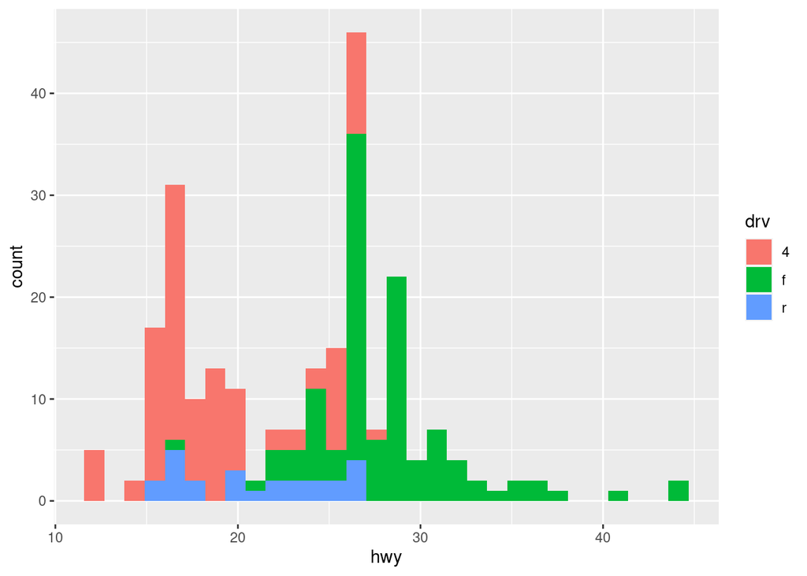

```r
ggplot(mpg, aes(x = hwy, fill = drv)) +
  geom_histogram(position = "stack")
```

# PART II - Refining your plot

## Managing scales

Whenever you specify an aesthetic mapping, `ggplot` uses a particular scale to determine the range of values that the data should map to. Thus when you specify

```r
# colour the data by engine type
ggplot(mpg, aes(x = displ, y = hwy, colour = class)) +
  geom_point()
```

ggplot automatically adds a scale for each mapping to the plot:

```r
# same as above, with explicit scales
ggplot(mpg, aes(x = displ, y = hwy, colour = class)) +
  geom_point() +
  scale_x_continuous() +
  scale_y_continuous() +
  scale_colour_discrete()
```

Each scale can be represented by a function with the following name: `scale_`, followed by the name of the aesthetic property, followed by an _ and the name of the scale. A `continuous` scale will handle things like numeric data (where there is a continuous set of numbers), whereas a `discrete` scale will handle things like colours (since there is a small list of distinct colours).

While the default scales will work fine, it is possible to explicitly add different scales to replace the defaults. For example, you can use a scale to change the direction of an axis:

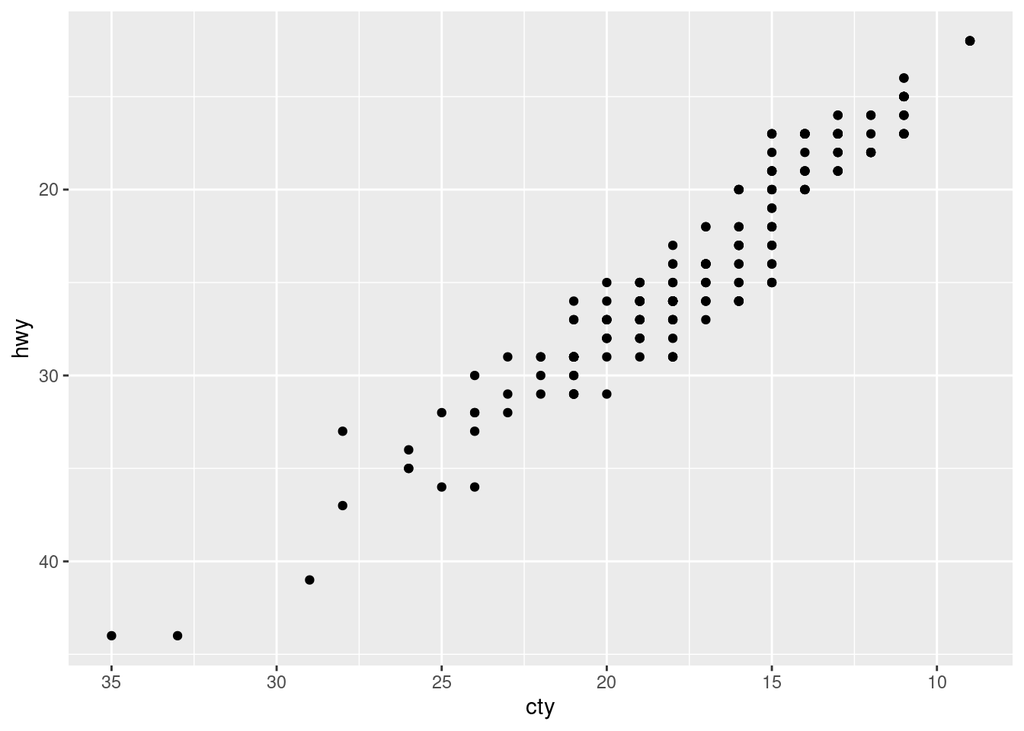

```r
# milage relationship, ordered in reverse
ggplot(mpg, aes(x = cty, y = hwy)) +
  geom_point() +
  scale_x_reverse() +
  scale_y_reverse()
```

Similarly, you can use `scale_x_log10()` and `scale_x_sqrt()` to transform your scale. You can also use scales to format your axes:

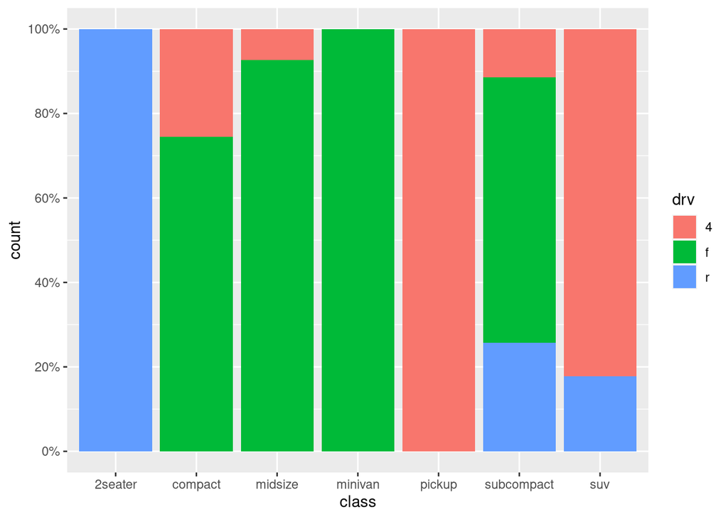

```r
ggplot(mpg, aes(x = class, fill = drv)) +
  geom_bar(position = "fill") +
  scale_y_continuous(breaks = seq(0, 1, by = .2), labels = scales::percent)
```

A common parameter to change is which set of colours to use in a plot. While you can use the default colouring, a more common option is to leverage the pre-defined palettes from [colourbrewer.org](https://colourbrewer2.org/). These colour sets have been carefully designed to look good and to be viewable to people with certain forms of colour blindness. We can leverage colour brewer palletes by specifying the `scale_colour_brewer()` function, passing the pallete as an argument.

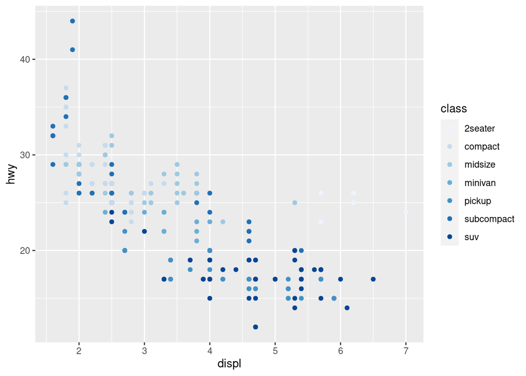

```r
# default colour brewer
ggplot(mpg, aes(x = displ, y = hwy, colour = class)) +
  geom_point() +
  scale_colour_brewer()
```

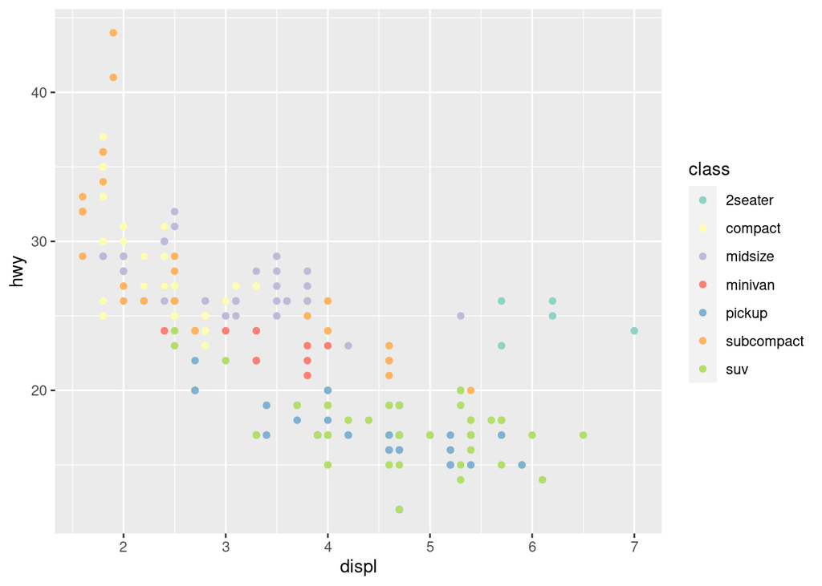

```r
# specifying colour palette
ggplot(mpg, aes(x = displ, y = hwy, colour = class)) +
  geom_point() +
  scale_colour_brewer(palette = "Set3")
```

You can also specify continuous colour values by using a gradient scale, or manually specify the colours you want to use as a named vector.